# One question, start to finish: worked solutions

PCB 6455 / BSC 4933: Biometry | Lecture 22

Dr. Brian Maitner

## How to use this

The code from Lecture 22, run, with the numbers it produces, and the coral exercises solved.

The simulations and draws are random, so your last decimal place may differ from mine. Anything beyond that is worth asking about.

## Setting up

```r
library(bbmle)
library(emdbook)

tosca_rov <- read.csv("https://github.com/bmaitner/biometry_course/raw/refs/heads/main/data/Deep_sea_megabenthos/TOSCA_ROV.csv")

rov <- data.frame(dive = tosca_rov$Dive.no,
                  depth = tosca_rov$Depth.water..m.,
                  substrate = tosca_rov$Substrate,
                  fov = tosca_rov$FOV.camera..m.,
                  sponges = tosca_rov$Porifera....,
                  corals = tosca_rov$Cnidaria....)      # all cnidarians, mostly corals
rov <- rov[!is.na(rov$fov), ]
rov$area <- 50 * rov$fov
rov$depth_km <- (rov$depth - 1500) / 1000
nrow(rov)
```

```
[1] 729
```

With the course package installed, `library(biometrydata)` gives the same `tosca_rov` table.

## Step 2: the data

```r
table(rov$substrate)
```

```
         bedrock biogenic gravels         boulders           gravel
             264               46              153              106
            sand
             160
```

```r
mean(rov$sponges == 0)
```

```
[1] 0.1316872
```

```r
rov$density <- 100 * rov$sponges / rov$area
tapply(rov$density, rov$substrate, median)
```

```
         bedrock biogenic gravels         boulders           gravel
       41.211215        38.973754        15.246637         5.098278
            sand
        4.363951
```

## Step 3: the distribution

```r
m_pois <- mle2(sponges ~ dpois(lambda = exp(log_d) * area / 100),
               start = list(log_d = 0), data = rov)
m_nb   <- mle2(sponges ~ dnbinom(mu = exp(log_d) * area / 100, size = exp(log_k)),
               start = list(log_d = 0, log_k = 0), data = rov)
m_zinb <- mle2(sponges ~ dzinbinom(mu = exp(log_d) * area / 100, size = exp(log_k),
                                   zprob = plogis(logit_z)),
               start = list(log_d = 0, log_k = 0, logit_z = -2), data = rov)
AICtab(m_pois, m_nb, m_zinb)
```

```
       dAIC     df
m_nb        0.0 2
m_zinb      1.9 3
m_pois 111088.1 1
```

## Step 4: build

```r
m_sub <- mle2(sponges ~ dnbinom(mu = exp(log_d) * area / 100, size = exp(log_k)),
              start = list(log_d = 0, log_k = 0),
              parameters = list(log_d ~ substrate - 1), data = rov)
m_depth <- mle2(sponges ~ dnbinom(mu = exp(log_d + b * depth_km) * area / 100,
                                  size = exp(log_k)),
                start = list(log_d = 0, b = 0, log_k = 0), data = rov)
m_both <- mle2(sponges ~ dnbinom(mu = exp(log_d + b * depth_km) * area / 100,
                                 size = exp(log_k)),
               start = list(log_d = 0, b = 0, log_k = 0),
               parameters = list(log_d ~ substrate - 1), data = rov)
```

## Steps 5 and 6: check and compare

```r
m_both_2 <- update(m_both, start = list(log_d = 3, b = -1, log_k = 1))
c(m_both@details$convergence, m_both@min, m_both_2@min)
```

```
[1]    0.000 3640.154 3640.154
```

```r
AICtab(m_nb, m_sub, m_depth, m_both, weights = TRUE)
```

```
        dAIC  df weight
m_both    0.0 7  1
m_sub    16.5 6  <0.001
m_nb    220.2 2  <0.001
m_depth 220.7 3  <0.001
```

```r
round(exp(coef(m_both)), 2)
```

```
         log_d.substratebedrock log_d.substratebiogenic gravels
                          60.90                           98.31
        log_d.substrateboulders           log_d.substrategravel
                          25.67                            6.91
            log_d.substratesand                               b
                           9.08                            1.70
                          log_k
                           0.51
```

## Step 7: the zeros check

```r
set.seed(7)
mu_hat <- predict(m_both)
k_hat <- exp(coef(m_both)["log_k"])
fake_zeros <- replicate(1000, {
  fake <- rnbinom(nrow(rov), mu = mu_hat, size = k_hat)
  tapply(fake == 0, rov$substrate, mean)
})
round(cbind(observed = tapply(rov$sponges == 0, rov$substrate, mean),
            lower = apply(fake_zeros, 1, quantile, 0.025),
            upper = apply(fake_zeros, 1, quantile, 0.975)), 3)
```

```
                 observed lower upper
bedrock             0.034 0.030 0.087
biogenic gravels    0.000 0.000 0.130
boulders            0.131 0.039 0.124
gravel              0.245 0.104 0.255
sand                0.256 0.094 0.200
```

Sand has far more empty sections than the model can produce, boulders a few more, and gravel sits at the top of its range.

## Step 7: the zero model

```r
rov$sediment <- as.numeric(rov$substrate %in% c("sand", "gravel", "boulders"))
# the on/off switch: sediment * plogis(logit_z) is 0 on rock, plogis(logit_z) on sediment
m_zero <- mle2(sponges ~ dzinbinom(mu = exp(log_d + b * depth_km) * area / 100,
                                   size = exp(log_k), zprob = sediment * plogis(logit_z)),
               start = list(log_d = 3, b = 0.5, log_k = -0.7, logit_z = -2),
               parameters = list(log_d ~ substrate - 1), data = rov)
AICtab(m_both, m_zero)
```

```
       dAIC df
m_zero  0.0 8
m_both 28.9 7
```

## Step 7: checking the zero model

```r
# predict() does not work for dzinbinom fits, so compute the mean by hand
cz <- coef(m_zero)
mu_zero <- exp(cz[paste0("log_d.substrate", rov$substrate)] + cz["b"] * rov$depth_km) *
  rov$area / 100
set.seed(8)
fake_zeros2 <- replicate(1000, {
  fake <- rzinbinom(nrow(rov), mu = mu_zero, size = exp(cz["log_k"]),
                    zprob = rov$sediment * plogis(cz["logit_z"]))
  tapply(fake == 0, rov$substrate, mean)
})
round(cbind(observed = tapply(rov$sponges == 0, rov$substrate, mean),
            lower = apply(fake_zeros2, 1, quantile, 0.025),
            upper = apply(fake_zeros2, 1, quantile, 0.975)), 3)
```

```
                 observed lower upper
bedrock             0.034 0.011 0.057
biogenic gravels    0.000 0.000 0.087
boulders            0.131 0.118 0.229
gravel              0.245 0.151 0.321
sand                0.256 0.150 0.275
```

Every substrate is now inside its simulated range.

## Step 8: intervals

```r
set.seed(22)
draws <- MASS::mvrnorm(1000, mu = coef(m_zero), Sigma = vcov(m_zero))

quantile(exp(draws[, "log_d.substratebedrock"] - draws[, "log_d.substratesand"]),
         c(0.025, 0.975))
```

```
    2.5%    97.5%
4.375679 7.598680
```

```r
quantile(exp(draws[, "b"]), c(0.025, 0.975))
```

```
    2.5%    97.5%
1.219398 1.897434
```

```r
quantile(plogis(draws[, "logit_z"]), c(0.025, 0.975))
```

```
      2.5%      97.5%
0.08590098 0.18464037
```

## Step 8: a band for the figure

```r
library(ggplot2)
grid <- expand.grid(depth = seq(900, 2900, by = 50), substrate = c("bedrock", "sand"))
grid$depth_km <- (grid$depth - 1500) / 1000
col_d <- paste0("log_d.substrate", grid$substrate)
curves <- matrix(NA, nrow = 1000, ncol = nrow(grid))
for (i in 1:1000) {
  curves[i, ] <- exp(draws[i, col_d] + draws[i, "b"] * grid$depth_km)
}
grid$lower <- apply(curves, 2, quantile, 0.025)
grid$upper <- apply(curves, 2, quantile, 0.975)
grid$density <- exp(coef(m_zero)[col_d] + coef(m_zero)["b"] * grid$depth_km)
grid[grid$depth == 1500, ]
```

```
   depth substrate depth_km     lower    upper  density
13  1500   bedrock        0 53.502873 75.97920 63.75012
54  1500      sand        0  8.663847 14.30839 11.16551
```

## Step 8: the figure

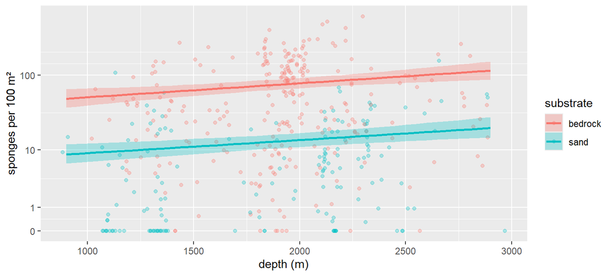

```r
ggplot(grid, aes(x = depth, y = density, color = substrate, fill = substrate)) +
  geom_point(data = rov[rov$substrate %in% c("bedrock", "sand"), ], alpha = 0.3) +
  geom_ribbon(aes(ymin = lower, ymax = upper), alpha = 0.3, color = NA) +
  geom_line(linewidth = 1) +
  scale_y_continuous(trans = "log1p", breaks = c(0, 1, 10, 100, 1000)) +
  labs(x = "depth (m)", y = "sponges per 100 m²")
```

## Step 8: in biology

Where sponges can settle, they are about 6 times as dense on bedrock as on sand; about 1 in 8 sections on sand, gravel or boulders has none at all; and on the same substrate, density rises about 1.5 times per km deeper.

## Your turn: corals, the four models

```r
c_nb <- mle2(corals ~ dnbinom(mu = exp(log_d) * area / 100, size = exp(log_k)),
             start = list(log_d = 0, log_k = 0), data = rov)
c_sub <- mle2(corals ~ dnbinom(mu = exp(log_d) * area / 100, size = exp(log_k)),
              start = list(log_d = 0, log_k = 0),
              parameters = list(log_d ~ substrate - 1), data = rov)
c_depth <- mle2(corals ~ dnbinom(mu = exp(log_d + b * depth_km) * area / 100,
                                 size = exp(log_k)),
                start = list(log_d = 0, b = 0, log_k = 0), data = rov)
c_both <- mle2(corals ~ dnbinom(mu = exp(log_d + b * depth_km) * area / 100,
                                size = exp(log_k)),
               start = list(log_d = 0, b = 0, log_k = 0),
               parameters = list(log_d ~ substrate - 1), data = rov)
AICtab(c_nb, c_sub, c_depth, c_both, weights = TRUE)
```

```
        dAIC  df weight
c_both    0.0 7  1
c_depth 194.7 3  <0.001
c_sub   281.2 6  <0.001
c_nb    343.9 2  <0.001
```

## Your turn: how much does depth matter?

```r
set.seed(23)
c_draws <- MASS::mvrnorm(1000, mu = coef(c_both), Sigma = vcov(c_both))
exp(coef(c_both)["b"])
```

```
         b
0.08443738
```

```r
quantile(exp(c_draws[, "b"]), c(0.025, 0.975))
```

```
      2.5%      97.5%
0.06335277 0.10978060
```

On the same substrate, coral density falls by about 92% for every kilometer of depth (89% to 94%).

## For anyone fast: corals, steps 2 and 3

```r
mean(rov$corals == 0)
```

```
[1] 0.2194787
```

```r
c(mean = mean(rov$corals), variance = var(rov$corals))
```

```
      mean   variance
  19.89438 1079.38855
```

```r
c_pois <- mle2(corals ~ dpois(lambda = exp(log_d) * area / 100),
               start = list(log_d = 0), data = rov)
c_zinb <- mle2(corals ~ dzinbinom(mu = exp(log_d) * area / 100, size = exp(log_k),
                                  zprob = plogis(logit_z)),
               start = list(log_d = 0, log_k = 0, logit_z = -2), data = rov)
AICtab(c_pois, c_nb, c_zinb)
```

```
       dAIC    df
c_nb       0.0 2
c_zinb     2.0 3
c_pois 28065.8 1
```

The negative binomial wins again, and zero inflation adds nothing with one density everywhere, the same as for sponges.